# Task 2: Palmetto binary logistic regression

Kirsten Hodgson

2/6/2021

```r
#Read in data
palmetto <- read.csv(here("data", "palmetto.csv")) %>%
  mutate(species_name = case_when(species == 1 ~ "Serenoa repens",
                             species == 2 ~ "Sabal etonia"))

palmetto$species <- as.factor(palmetto$species)
```

Data source: Abrahamson, W.G. 2019. Survival, growth and biomass estimates of two dominant palmetto species of south-central Florida from 1981 - 2017, ongoing at 5-year intervals ver 1. Environmental Data Initiative. https://doi.org/10.6073/pasta/f2f96ec76fbbd4b9db431c79a770c4d5

### Data Visualization

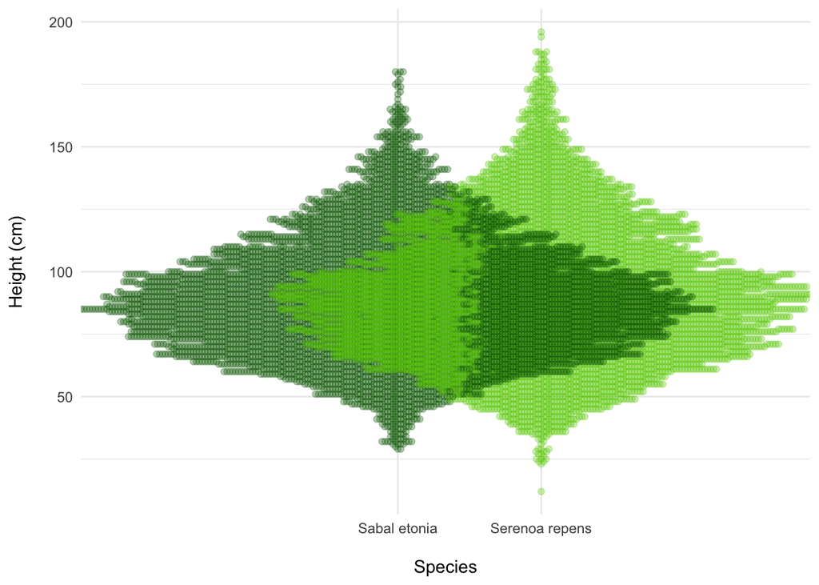

```r
#Visualizing differences in height
ggplot(data = palmetto, aes(x = species_name,
                                    y = height,
                                    color = species_name)) +
  geom_beeswarm(alpha = 0.3) +
  theme_minimal() +
  theme(legend.position = "none") +
  labs(x = "\nSpecies", y = "Height (cm)\n") +
  scale_color_manual(values = c("darkgreen", "chartreuse3"))
```

**Figure 1.** Height (cm) distributed by species for *Sabal etonia* (dark green) and *Serenoa repens* (light green). Width and darkness of beeswarm plot indicates number of observations at each height for that species.

This beeswarm shows that overall, *Sabal etonia* and *Serenoa repens* are similar in height. While *S. repens* appears to have more observations of larger height, and has a higher maximum observed height than *S. etonia*, without further analysis it cannot be determined whether this difference is the result of sampling variability or indicative of a trend.

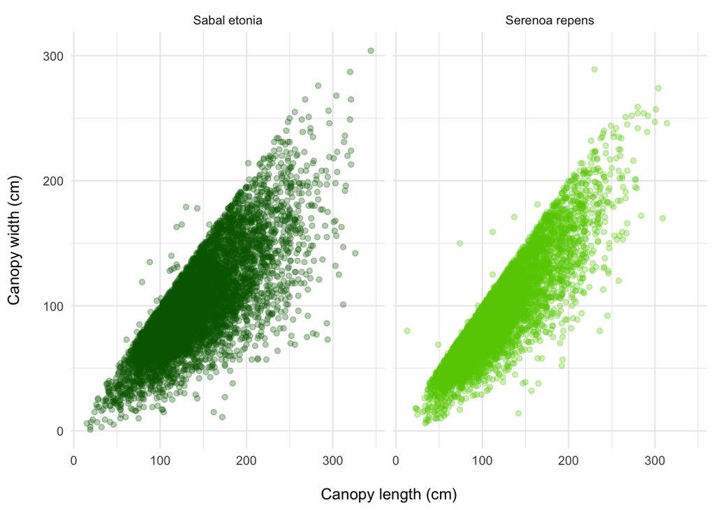

```r
#Visualizing differences in canopy length and canopy width
  ggplot(data = palmetto, aes(x = length,
                              y = width,
                              color = species_name)) +
  facet_grid(~species_name) +
  geom_point(alpha = 0.3) +
  theme_minimal() +
  theme(legend.position = "none") +
  labs(x = "\nCanopy length (cm)", y = "Canopy width (cm)\n") +
  scale_color_manual(values = c("darkgreen", "chartreuse3"))
```

**Figure 2.** Canopy width (cm) vs. canopy length (cm) for *Sabal etonia* (dark green) and *Serenoa repens* (light green).

Both species appear to have a near linear relationship between canopy width and canopy height. However, *S. etonia* does appear to have more longer canopies overall, as well as more canopies that are longer and narrower than *S repens*.

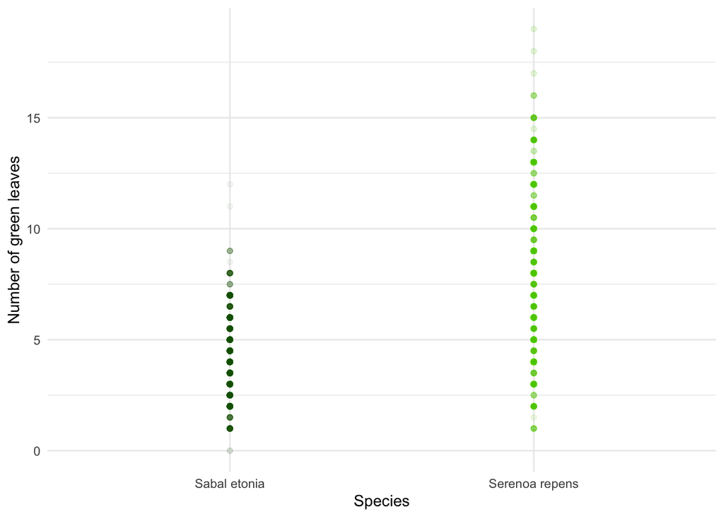

```r
#Visualizing green leaves
  ggplot(data = palmetto, aes(x = species_name,
                             y = green_lvs,
                             color = species_name)) +
  geom_point(alpha = 0.05) +
  theme_minimal() +
  theme(legend.position = "none") +
  labs(x = "Species", y = "Number of green leaves") +
  scale_color_manual(values = c("darkgreen", "chartreuse3"))
```

**Figure 3.** Distribution of the number of green leaves observed on individual of *Sabal etonia* (dark green) and *Serenoa repens* (light green). Darker points indicate more observations of that number of green leaves per species.

While *S. etonia* and *S. repens* have similar lower ends of their distributions of green leaves, the upper end of *S. repens* distribution appears to be greater than that of *S. etonia*.

### Binary logistic regression

To classify species based on:

- plant height (cm)
- canopy length (cm)
- canopy width (cm)
- number of green leaves

**Table 1.** Outcome of binomial linear regression using plant height (height), canopy length (length), canopy width (width), and number of green leaves (green_lvs) as predictor variables of palmetto species. Here, the zero level is *Serenoa repens*, so the estimates represent the change in likelihood that a palmetto is species *Sabal etonia* with each one unit increase in the given predictor variable.

```r
palmetto_blr <- glm(species ~ height + length + width + green_lvs,
                    data = palmetto,
                    family = "binomial")
#Non-zero level: 2 (Sabal etonia)

palmetto_blr_tidy <- tidy(palmetto_blr)

blr_table <- palmetto_blr_tidy %>%
  mutate_if(is.numeric, funs(as.character(signif(.,3)))) %>%
  kable(col.names = c("Variable", "Estimate", "Standard Error", "Statistic", "p-value"),  digits = 4) %>%
  kable_styling(full_width = T)

blr_table
```

| Variable | Estimate | Standard Error | Statistic | p-value |
| --- | --- | --- | --- | --- |
| (Intercept) | 3.23 | 0.142 | 22.7 | 3.42e-114 |
| height | -0.0292 | 0.00231 | -12.7 | 8.69e-37 |
| length | 0.0458 | 0.00187 | 24.6 | 3.73e-133 |
| width | 0.0394 | 0.0021 | 18.8 | 1.05e-78 |
| green_lvs | -1.91 | 0.0389 | -49.1 | 0 |

### Evaluating model success

**Table 2.** The number of correct, number of incorrect, and percent of correct predictions from `palmetto_blr` binomial linear regression model. The model uses height, crown length, crown width, and number of green leaves to to correctly predict palmetto species more than 90% of the time (92.6% accuracy for *S. etonia*, 90.8% accuracy for *S. repens*).

```r
blr_fitted <- palmetto_blr %>%
  broom::augment(type.predict = "response") %>%
  mutate(predicted = case_when(.fitted >= 0.5 ~ 2,
                               .fitted <= 0.5 ~ 1))

blr_correct <- blr_fitted %>%
  mutate(correct = case_when(predicted == species ~ "correct",
                             TRUE ~ "incorrect")) %>%
  mutate(species = case_when(species == 1 ~ "Serenoa repens",
                             species == 2 ~ "Sabal etonia")) %>%
  select(species, .fitted, predicted, correct) %>%
  group_by(species, correct) %>%
  summarize(number_correct = n())  %>%
  pivot_wider(names_from = correct,
              values_from = number_correct) %>%
  mutate(percent_correct = ((correct/(correct + incorrect))*100)) %>%
  kable(col.names = c("Species", "Number correct", "Number incorrect", "Percent correct")) %>%
  kable_styling(full_width = T)

blr_correct
```

| Species | Number correct | Number incorrect | Percent correct |
| --- | --- | --- | --- |
| Sabal etonia | 5701 | 454 | 92.62388 |
| Serenoa repens | 5548 | 564 | 90.77225 |